# funTDA — Part B: time series baseline (Tribolium beetle model)

- Show All Code
- Hide All Code
- View Source

Persistence landscapes, FPCA, and functional permutation tests over 400 simulated series

Author

Victoria Arroniz

Published

July 30, 2026

## Data

This is Part B of the funTDA project: the same persistence-landscape-based functional data analysis (FDA) pipeline used in Part A for gene regulatory networks, applied here to **simulated time series** instead. The system is the Tribolium flour beetle population model of Costantino et al. (1995). Pereira & de Mello (2015) is the reference for applying persistent homology to time series via Takens-delay-embedded point clouds, the general approach `beetles_landscapes.ipynb` follows here; this document has not independently verified that Pereira & de Mello’s own worked examples use the Tribolium model specifically, as opposed to some other time series.

The discrete-time model tracks three life stages (larvae `L`, pupae/callow adults `P`, mature adults `A`) in two-week intervals. Two parameter regimes are simulated, 200 series each, 201 time steps, with initial conditions `L0, P0, A0 ~ U[2, 100]`:

- **Stable** (`u_a = 0.73`, adult death rate): the population converges to a fixed-point equilibrium.
- **Aperiodic** (`u_a = 0.96`): the population oscillates chaotically.

**NoteThis functional test is new, not a reproduction**

Two things distinguish this document from a re-run of prior work:

1. **Higgins, Wu & Carey’s funTDA paper does not analyze time series at all.** Its worked examples are all networks — Erdős–Rényi graphs, stochastic block models, a literary character network, and the H3N2 gene regulatory networks used in Part A. Applying the funTDA landscape + FPCA + permutation-test pipeline to time series is an extension of the method to a data modality the original paper never covers.
2. **The original `Example1Beetles.Rmd` does not run this functional hypothesis test either.** It runs two *independent* classification checks, each against the true regime labels, each reported as its own confusion matrix:
   1. k-means clustering of the raw (unnormalized) series into two groups, compared to the true labels (`cfm <- table(correct, km_clusters)`), and separately (b) a rule that calls a series “correctly” classified if its single most persistent bar has dimension 0 (stable) or 1 (aperiodic), again compared to the true labels (`cfm_hom`) — not to the k-means clusters from (a). The two checks are never compared to each other. There is no landscape, no FPCA, and no permutation test in it — both are classification-accuracy checks against ground truth, not a test of functional equality between group means.

The FPCA and permutation test below are therefore a genuinely new analysis, not a reproduction of a previously reported number — unlike Part A, there is no prior “baseline” p-value or variance-explained figure to match. The `ref` values in this document’s source are sanity checks from an earlier direct computation on these same committed arrays, not an external ground truth.

## Pipeline: from simulated series to functional landscapes

The full pipeline — simulation, per-series min-max normalisation to `[0, 1]`, Takens delay embedding ($m = 2$, $\tau = 3$), Vietoris–Rips persistent homology via `ripser` (the same underlying algorithm `TDAstats::calculate_homology` uses in R), and the first H1 persistence landscape layer (`KK = 1`) on a shared 500-point grid — is implemented in Python, in `beetles_landscapes.ipynb`. The grid there is **data-adaptive**: `tseq = linspace(global_min_birth, global_max_death, 500)`, rather than the fixed `[0, 1]` Part A could use, because Rips filtration values on a normalised phase-space point cloud don’t have a natural upper bound of 1.

That notebook saves three arrays (`stable_landscapes.npy`, shape `(200, 500)`; `aperiodic_landscapes.npy`, shape `(200, 500)`; `tseq.npy`, shape `(500,)`). `export_landscapes.py` converts them to the CSVs this document reads (`output/stable_landscapes.csv`, `output/aperiodic_landscapes.csv`, `output/tseq.csv`) — mirroring Part A’s split between a Python stage that computes persistent homology and an R stage that does the functional data analysis. The landscapes are **not** re-simulated or re-computed here: doing so is slow (ripser over 400 point clouds), and Python’s and R’s random number generators aren’t interchangeable, so re-simulating in R would not reproduce these particular 400 series anyway. The committed CSVs are the single source of truth for everything that follows.

**NoteReused figures from `make_figs.py`**

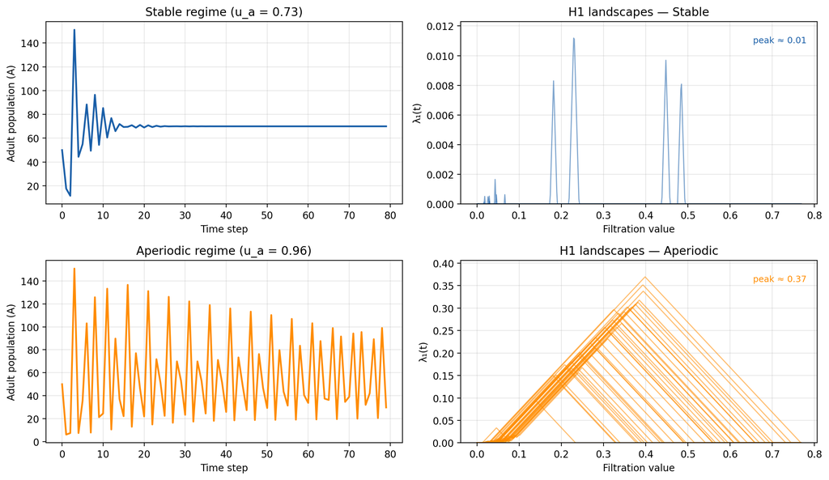

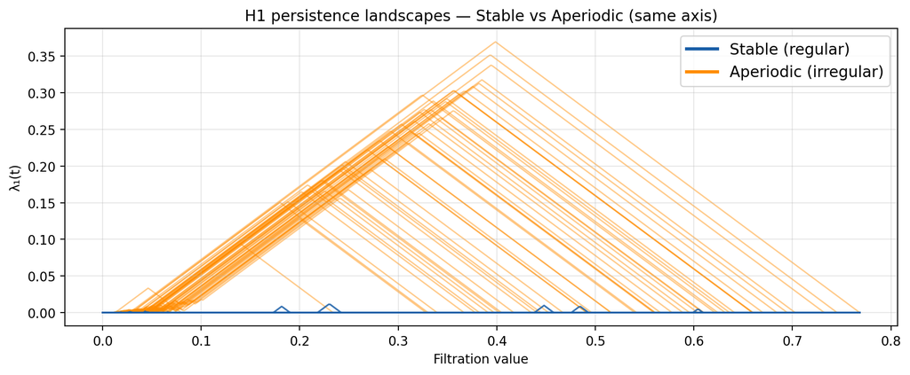

H1 landscapes for both regimes overlaid on the same axis: the stable regime’s small transient loops sit near zero against the much larger aperiodic ones (generated by `make_figs.py`, reused as-is).

### Structural check: most stable landscapes are identically zero

**129 of the 200 stable series (64%) have a landscape that is identically zero** across the whole grid, versus **0 of 200** aperiodic series. `u_a = 0.96` drives sustained oscillation, whose attractor is a closed orbit — an H1 loop that the landscape detects directly, so `n_aperiodic_zero = 0` reflects a genuinely empty diagram’s absence. The stable case is more subtle and, on its own, easy to over-read: **these 129 series do not have empty H1 diagrams.** Every stable series still carries the decaying spiral of its approach to the `u_a = 0.73` fixed point, which is a closed curve in the Takens embedding and therefore does register an H1 feature — just one short-lived enough that no point of the shared 500-point grid falls inside its birth–death interval, so the *sampled* landscape reads as zero even though the feature exists. “The approach-to-equilibrium transient” section below derives why this spiral exists and quantifies the gap between feature lifetime and grid spacing. Consistent with a real but small signal rather than a true absence, the mean of each series’ landscape peak is **0.0016** for stable series versus **0.2274** for aperiodic ones — roughly a 150-fold difference in typical peak height, not a zero-vs- nonzero one.

## Functional Principal Component Analysis (FPCA)

Identical smoothing to `funTDA.R`: an order-2 (piecewise-linear) B-spline basis with `nbasis = 499` (one fewer than the 500 grid points), so the basis nearly interpolates the raw landscape values. The only difference from Part A is the basis range: `range(tseq)` here (the data-adaptive Rips scale, about `[0, 0.77]`) instead of the fixed `[0, 1]` Part A could use. PC1’s sign is fixed by convention (stable series score negative) immediately after `pca.fd`, since an eigenvector’s sign is otherwise arbitrary — see the code below.

Variance explained by the first two functional components

| Component | % variance explained |
| --- | --- |
| PC1 | 84.29% |
| PC2 | 12.67% |
| Cumulative (PC1+PC2) | 96.96% |

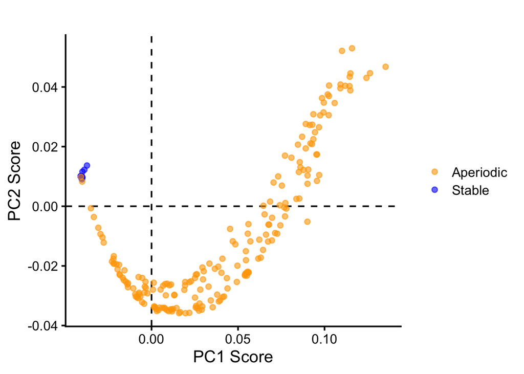

PC1 vs PC2 scores (FPCA over H1 landscapes), colored by regime. All 400 points are individual series; no per-point labels, unlike Part A’s 17-subject plot, since labeling 400 points would be unreadable — see the full score table below for per-series values.

**NoteFull FPC scores (all 400 series)**

| ID | Group | PC1 | PC2 |
| --- | --- | --- | --- |
| Stable1 | Stable | -0.0408 | 0.0100 |
| Stable2 | Stable | -0.0408 | 0.0100 |
| Stable3 | Stable | -0.0408 | 0.0100 |
| Stable4 | Stable | -0.0408 | 0.0100 |
| Stable5 | Stable | -0.0408 | 0.0100 |
| Stable6 | Stable | -0.0408 | 0.0100 |
| Stable7 | Stable | -0.0408 | 0.0100 |
| Stable8 | Stable | -0.0408 | 0.0100 |
| Stable9 | Stable | -0.0408 | 0.0100 |
| Stable10 | Stable | -0.0408 | 0.0100 |
| Stable11 | Stable | -0.0408 | 0.0100 |
| Stable12 | Stable | -0.0408 | 0.0100 |
| Stable13 | Stable | -0.0408 | 0.0100 |
| Stable14 | Stable | -0.0408 | 0.0100 |
| Stable15 | Stable | -0.0407 | 0.0101 |
| Stable16 | Stable | -0.0408 | 0.0100 |
| Stable17 | Stable | -0.0408 | 0.0100 |
| Stable18 | Stable | -0.0408 | 0.0100 |
| Stable19 | Stable | -0.0408 | 0.0100 |
| Stable20 | Stable | -0.0408 | 0.0100 |
| Stable21 | Stable | -0.0408 | 0.0100 |
| Stable22 | Stable | -0.0408 | 0.0100 |
| Stable23 | Stable | -0.0408 | 0.0100 |
| Stable24 | Stable | -0.0408 | 0.0100 |
| Stable25 | Stable | -0.0408 | 0.0100 |
| Stable26 | Stable | -0.0408 | 0.0100 |
| Stable27 | Stable | -0.0408 | 0.0100 |
| Stable28 | Stable | -0.0408 | 0.0100 |
| Stable29 | Stable | -0.0408 | 0.0100 |
| Stable30 | Stable | -0.0408 | 0.0100 |

[output cut: 370 more lines]

**NoteSanity checks — FPCA**

| Metric | Sanity-check value | Computed here |
| --- | --- | --- |
| PC1 | ~84% | 84.29% |
| PC2 | ~13% | 12.67% |
| Cumulative | ~97% | 96.96% |
| Stable with PC1 < 0 | 200 / 200 | 200 / 200 |
| Aperiodic with PC1 < 0 | ~42 / 200 | 42 / 200 |

The first two functional components explain **97.0%** of the variability among landscapes (PC1 $\approx$ 84.3%, PC2 $\approx$ 12.7%). All 200 stable series fall in the PC1 < 0 half-plane — unsurprising, since 129 of them share the exact same (identically-zero) landscape and so collapse to nearly the same point in function space. Separation is **not** perfect, though: **42 of the 200 aperiodic series** (21%) also fall in PC1 < 0, overlapping the stable cloud.

This is a genuine limitation of the fixed embedding parameters ($m = 2$, $\tau = 3$), not of the FDA pipeline: for some aperiodic trajectories, this particular embedding does not produce a topologically prominent loop — the reconstructed attractor stays close enough to a compact blob that its H1 landscape resembles a stable series’ near-zero landscape. Takens’ theorem guarantees a *generic* embedding recovers the attractor topology, but $(m, \tau)$ are fixed constants here, not tuned per series; a natural extension would be a sensitivity analysis over $(m, \tau)$ to check whether a higher embedding dimension or a different delay recovers the loop for these borderline series.

## Functional permutation test: stable vs. aperiodic

This reuses the same vectorized max-$T$ permutation test from Part A — already validated bit-for-bit there against `fda::tperm.fd` — evaluating each `fd` object on a 101-point grid and permuting columns of a matrix instead of re-evaluating `fd` on every permutation. The masked version below is mathematically identical to that validated function whenever every grid point’s denominator is positive: that is the case for every grid point in every test Part A ever ran (its GRN landscapes never included an identically-zero one), so Part A’s bit-for-bit validation carries over directly to those points. What is new here is a defensive guard for a case Part A’s data never exercised.

**ImportantA defensive guard for a zero-variance denominator (does not trigger with this data)**

The Welch-style test statistic at each grid point $t$ is $\lvert \bar{x}_1(t) - \bar{x}_2(t) \rvert / \sqrt{v_1(t) + v_2(t)}$, and the final statistic is the supremum over $t$. Because 129 of the 200 stable series are identically zero, the stable group’s pointwise variance $v_1(t)$ is minuscule almost everywhere, and at the very edges of the shared grid range — where essentially no series in *either* group has accumulated any persistence yet — both groups’ variances could in principle hit exact floating-point zero, making the ratio the undefined form 0/0. Part A’s networks never produced an identically-zero landscape, so this case never had to be guarded against there.

The guard excludes grid points with a zero denominator from the supremum, rather than let a stray `NaN` or `Inf` propagate into `max()` unnoticed:

```r
den <- v1 + v2
valid <- den > 0
max(abs(m1[valid] - m2[valid]) / sqrt(den[valid]))
```

With the actual committed data, this guard turns out **not to be needed** in practice (confirmed just below, computed live from the same objects the test uses): after B-spline smoothing, the boundary points evaluate to tiny floating-point residues (of order $10^{-13}$ to $10^{-88}$) rather than exact zero, so they pass the `den > 0` filter and contribute a small, well-defined statistic value rather than an undefined one. The guard is kept anyway, as a correctness safeguard rather than a currently-active code path: a slightly different smoothing, grid, or platform could in principle produce an exact zero, and silently propagating a `NaN` into a `max()` would be a much worse failure mode than an unused `if`.

**ImportantStable vs. Aperiodic test result**

- **Observed T_max** = 85.51 (sanity check: ~85.5)
- **Critical value (95%)** = 2.75 (sanity check: ~2.85)
- **p-value** = 0.00000 (out of 10000 permutations — a value of 0 here means p < 1e-4, not exactly zero)

This is expected given how the two regimes were constructed (one produces topological loops, the other does not), but the result itself is new: `Example1Beetles.Rmd` never asked this question in a functional-hypothesis-testing sense. It runs two independent classification checks against the true regime labels — k-means clustering on the raw series (`cfm`) and a rule based on which homology dimension each series’ single most persistent bar belongs to (`cfm_hom`) — and reports each as its own confusion matrix; the two checks are never compared against each other, and neither is a test of functional equality between group means. The permutation test here instead directly tests whether the *entire mean landscape curves* differ, which is the same kind of claim Part A makes about asymptomatic vs. symptomatic GRNs.

## Control analysis (within-regime calibration)

Part A’s split-half validation enumerated *every* possible partition of each group (`choose(9,4) = 126`, `choose(8,4) = 70`) because those groups were small enough to do so exhaustively. Here each regime has 200 series, and `choose(200, 100)` is on the order of $10^{58}$ — completely infeasible to enumerate. Instead, this is a **random sample of 200 balanced (100 vs. 100) splits per regime**, drawn with a fixed seed continuing directly from the main test’s RNG stream above (not “all partitions”, unlike Part A). Because these splits are all drawn from the same 200 series per regime (not 200 independent fresh samples), they are correlated with each other, so the mean/sd/fraction below understate the true sampling uncertainty somewhat — the same caveat applies, in a milder form, to Part A’s exhaustive enumeration, since overlapping subsets there are not independent either.

**NoteThe stable control is not as informative as the aperiodic one**

The two regimes’ control analyses are not equivalent evidence. 129 of the 200 stable series (64%) are identically zero, so a random 100-vs-100 split of the stable regime compares two halves that are, on average, **64%** identical zero curves each (computed live across the 200 splits actually drawn above) — it is substantially a “zeros vs. zeros” comparison, well calibrated close to trivially rather than as a demonstration that the test correctly handles genuine functional variability. The zero-variance guard from the previous section is, in fact, never triggered in these splits either: all 101 of 101 grid points are always valid (computed live, same as the main test above). The **aperiodic control is the informative one**: no aperiodic series is identically zero, so its 200 splits compare genuinely varying curves on the full, unmasked grid (101 of 101 points valid there too, for the unrelated reason that no aperiodic series has zero variance in the first place) — its calibration result is the one that should be read as evidence the test does not over-reject.

Summary of the within-regime control analysis

| Regime | mean p-value | sd(p-value) | % splits with p < 0.05 |
| --- | --- | --- | --- |
| Stable (200 random splits, 100 vs 100) | 0.534 | 0.297 | 5.0% |
| Aperiodic (200 random splits, 100 vs 100) | 0.505 | 0.282 | 4.0% |

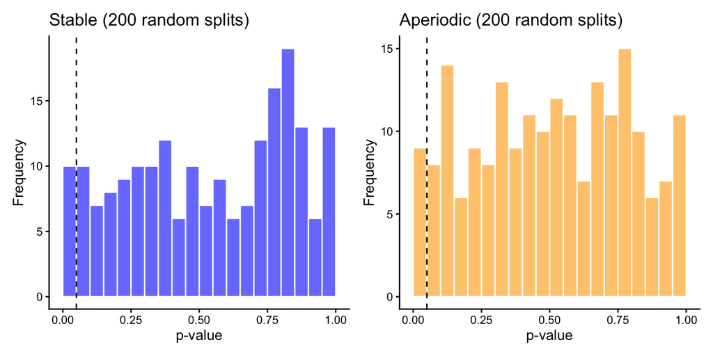

Distribution of control-analysis p-values, by regime (dashed line at p = 0.05).

**NoteSanity checks — control analysis**

| Regime | mean p | sd p | % p < 0.05 |
| --- | --- | --- | --- |
| Stable | 0.534 | 0.297 | 5.0% |
| Aperiodic | 0.505 | 0.282 | 4.0% |

Both regimes’ p-values are consistent with the nominal 5% false-positive rate expected under the null, but as noted above, only the **aperiodic** result is strong evidence that the test does not over-reject on genuinely varying functional data — the stable result is largely a check that comparing zero to zero correctly fails to reject, which is a much lower bar. Taken together, they still calibrate the significance of the stable-vs-aperiodic result above: the rejection there reflects a real difference between regimes, not a general tendency of the test to over-reject.

## The approach-to-equilibrium transient

Everything above uses `beetles_landscapes.ipynb` at its default `BURN_IN = 0`: the retained 201-step series starts right after the random initial condition, not after the population has settled onto its attractor — matching `Example1Beetles.Rmd`, which this chapter replicates and which never discards an initial transient either. This section makes that choice explicit. It (1) derives, in closed form, *why* the stable regime’s approach to equilibrium registers as an H1 loop at all; (2) corrects a claim that is easy to make too quickly from the structural check above — an identically-zero *landscape* is not the same thing as an empty H1 *diagram*; and (3) quantifies, via a dedicated `BURN_IN = 200` sensitivity run, how much of the topological signal is attributable to the transient, and why discarding it would have left the main analysis without a working calibration check. None of this changes the result above; it explains it.

### The mechanism: a damped spiral onto the fixed point

The stable regime (`u_a = 0.73`) is a point attractor: the deterministic LPA map has a single fixed point that every trajectory in this regime converges to. Finding it by direct iteration and linearising there (the Jacobian of the LPA map) characterises *how* that convergence happens:

```r
B_    <- 7.48; C_EA_ <- 0.009; C_PA_ <- 0.004; C_EL_ <- 0.012; U_L_ <- 0.267
U_A_STABLE_ <- 0.73

lpa_step_ <- function(state, u_a) {
  L <- state[1]; P <- state[2]; A <- state[3]
  c(
    B_ * A * exp(-C_EL_ * L - C_EA_ * A),
    L * (1 - U_L_),
    P * exp(-C_PA_ * A) + A * (1 - u_a)
  )
}

# The map is a contraction at the fixed point (see the Jacobian below), so
# direct iteration from an arbitrary interior starting point converges to
# machine precision regardless of where it starts.
state <- c(50, 30, 60)
for (i in 1:5000) state <- lpa_step_(state, U_A_STABLE_)
fixed_point <- state
names(fixed_point) <- c("L", "P", "A")
fixed_point
```

```
       L        P        A
92.21230 67.59162 69.98357
```

```r
lpa_jacobian_ <- function(state, u_a) {
  L <- state[1]; P <- state[2]; A <- state[3]
  e <- exp(-C_EL_ * L - C_EA_ * A)
  matrix(c(
    -C_EL_ * B_ * A * e, 0,                  B_ * e - C_EA_ * B_ * A * e,
    1 - U_L_,            0,                  0,
    0,                   exp(-C_PA_ * A),   -C_PA_ * P * exp(-C_PA_ * A) + (1 - u_a)
  ), nrow = 3, byrow = TRUE)
}

eig <- eigen(lpa_jacobian_(fixed_point, U_A_STABLE_))$values
eig
```

```
[1] -0.7457858+0.2082557i -0.7457858-0.2082557i  0.4506720+0.0000000i
```

```r
Mod(eig)
```

```
[1] 0.774317 0.774317 0.450672
```

```r
lambda_complex   <- eig[abs(Im(eig)) > 1e-8][1]
rotation_period  <- 2 * pi / abs(Arg(lambda_complex))
contraction_step <- Mod(lambda_complex)
```

The fixed point is `(L, P, A)` $\approx$ (92.212, 67.592, 69.984), and the Jacobian there has a **complex-conjugate eigenvalue pair** ($\lambda \approx$ -0.7458 $\pm$ 0.2083$i$, modulus $\approx$ 0.7743) alongside a real eigenvalue ($\approx$ 0.4507). A complex eigenvalue pair means the linearised dynamics near the fixed point are a **rotation composed with a contraction**: every trajectory spirals in rather than approaching monotonically. The rotation completes a full turn every $2\pi / |\mathrm{Arg}(\lambda)| \approx$ 2.19 steps, while each step shrinks the distance to the fixed point by a factor of $|\lambda| \approx$ 0.7743.

This matters for persistent homology specifically because **a spiral is a closed curve** when it is embedded in a delay-coordinate phase space: over one rotation period the trajectory loops most of the way around the fixed point before contracting to the next, smaller loop. Takens embedding turns this into a point cloud that traces something topologically indistinguishable, at the resolution of a single loop, from a genuine cycle — so Vietoris–Rips persistent homology registers an H1 feature for it, even though the spiral is not part of the attractor itself and vanishes (in principle, at infinite resolution) as $t \to \infty$. The stable regime’s attractor, the fixed point alone, truly has no loops; the finite-length *approach* to it does.

### The corrected claim: absence on the grid, not absence of homology

The structural check above found 129 of 200 stable landscapes identically zero on the shared evaluation grid. Read on its own, that number invites the conclusion “these series have no H1 features” — but that conclusion is wrong. Every stable series still carries the decaying spiral just derived, which is a genuine (if short-lived) H1 loop; the other 71 of 200 (36%) already show it directly, with a landscape that survives on the grid. A prior diagnostic run of `regime_diagnostics.py` (committed as `regime_diagnostics_output.txt`) makes the resolution effect explicit: over a fresh no-burn-in simulation, **every** stable series’ H1 diagram was non-empty, yet the median of each series’ maximum H1 lifetime was only `0.00022` — well below the shared grid’s point spacing, which is 0.00154 for the actual committed grid used throughout this document (`0.00153` for that diagnostic run’s own grid). A persistence landscape evaluates to zero at grid point $t$ whenever no birth–death interval contains $t$; a feature with lifetime shorter than the grid spacing can fail to contain *any* grid point purely by bad luck of where the birth falls relative to the nearest sample, independent of whether the feature is topologically real. So: the feature exists, and is invisible to this particular 500-point sampling, not absent. This is a sampling-resolution statement, not a homological one.

### Sensitivity run: discarding the transient (`BURN_IN = 200`)

To isolate the two **attractors** — comparing “fixed point” against “closed orbit” instead of “fixed point + approach spiral” against “closed orbit + approach transient” — `beetles_landscapes.ipynb` can be re-run with `BURN_IN = 200` (an *additional* 200 steps simulated and discarded before the retained 201-step series begins, so series length, embedding and grid are unchanged). That run is committed in `output_burnin/`, analysed here with exactly the same pipeline used for the main analysis above.

| Metric | Main (no burn-in) | Burn-in appendix |
| --- | --- | --- |
| Stable landscapes identically zero | 129 / 200 | 200 / 200 |
| Mean aperiodic landscape peak | 0.2274 | 0.3492 |
| PC1 / PC2 variance explained | 84.3% / 12.7% | 99.0% / 0.7% |
| Aperiodic with PC1 < 0 | 42 / 200 | 9 / 200 |
| Stable vs. aperiodic $T_{max}$ (crit95) | 85.51 (2.75) | 198.65 (2.58) |
| Within-stable control | defined (mean p $\approx$ 0.53) | undefined (degenerate) |

Discarding the transient does exactly what removing an approach spiral should do: every stable landscape collapses to identically zero (200/200, versus 129/200 with the transient retained), PC1 alone explains essentially all the variance (99.0%), and the stable-vs-aperiodic separation gets *sharper*, not weaker ($T_{max}$ 198.65 versus 85.51; aperiodic overlap into PC1 < 0 drops to 9/200 from 42/200).

**The compensation.** That sharper separation comes at a real cost: with every stable landscape collapsed to the same identically-zero curve, a within-stable split has **zero pooled variance at every grid point**, so `vtperm()`’s `NA_real_` guard (kept and explained in the code above) triggers for all 200 splits, and the within-stable calibration control that works in the main analysis becomes mathematically undefined here — there is no variability left to split. This is precisely why the main analysis above retains the transient: it is the only version of this pipeline in which the within-stable control is a meaningful check rather than an ungrounded “compare zero to zero” tautology, and losing that check to gain a cleaner-looking separation was judged not worth it, especially since the separation was already decisive (`p < 1e-4`) with the transient retained.

### Where the transient’s effect kicks in: a burn-in sweep

The two runs above are single points (`BURN_IN` 0 and 200) on a continuum. `beetles_landscapes.ipynb` sweeps a grid of burn-in values, each with a smaller 60-series-per-regime cohort (fixed seed, same model), recording how many stable series have a genuinely empty H1 diagram and the aperiodic regime’s mean landscape peak, written to `output/burnin_sweep.csv`:

```r
sweep <- read.csv("output/burnin_sweep.csv")
sweep$pct_stable_h1_empty <- sprintf("%.0f%%", 100 * sweep$n_stable_h1_empty / sweep$n_sweep)
knitr::kable(
  data.frame(
    `Burn-in`                    = sweep$burn_in,
    `Stable, H1 empty`           = sprintf("%d / %d (%s)", sweep$n_stable_h1_empty, sweep$n_sweep, sweep$pct_stable_h1_empty),
    `Mean aperiodic peak`        = sprintf("%.4f", sweep$mean_aperiodic_peak),
    check.names = FALSE
  ),
  align = "lrr"
)
```

| Burn-in | Stable, H1 empty | Mean aperiodic peak |
| --- | --- | --- |
| 0 | 0 / 60 (0%) | 0.2304 |
| 10 | 0 / 60 (0%) | 0.2655 |
| 25 | 0 / 60 (0%) | 0.2844 |
| 50 | 0 / 60 (0%) | 0.2986 |
| 100 | 0 / 60 (0%) | 0.3161 |
| 120 | 11 / 60 (18%) | 0.3213 |
| 140 | 59 / 60 (98%) | 0.3264 |
| 150 | 60 / 60 (100%) | 0.3296 |
| 160 | 60 / 60 (100%) | 0.3328 |
| 200 | 60 / 60 (100%) | 0.3435 |
| 400 | 60 / 60 (100%) | 0.3666 |
| 800 | 60 / 60 (100%) | 0.3715 |

The empirical transition is abrupt, not gradual: essentially none of the 60 stable series have an empty H1 diagram through burn-in 100, then almost all of them do by burn-in 140–150. That matches the mechanism derived above: because the stable regime’s approach is a *contraction*, its transient decays geometrically at rate $|\lambda| \approx$ 0.7743 per step, so there is a fairly sharp burn-in past which the spiral’s remaining radius falls below what any trajectory in this system can resolve — not a slow fade. Equating “remaining radius has shrunk by 16 orders of magnitude” ($16 \ln 10$, an arbitrary but generous margin) with $n$ steps of that contraction gives a threshold of $16\ln(10) / (-\ln|\lambda|) \approx$ 144 steps — close to where the sweep actually crosses over.

The aperiodic regime’s mean landscape peak, by contrast, is still visibly increasing at burn-in 200 (0.3435) and has not fully leveled off even by burn-in 800 (0.3715). This is consistent with the aperiodic regime’s own approach dynamics: `regime_diagnostics.py`’s Lyapunov spectrum for `u_a = 0.96` gives a near-zero exponent along the invariant curve itself (motion *on* the attractor does not decay) and a much smaller contracting exponent transverse to it, $\approx -0.0167$, versus the stable regime’s $-\ln|\lambda| \approx$ 0.2558 derived above — the aperiodic transient decays roughly 15.3 times more slowly per step than the stable one, not the “about 40 times” this document’s brief anticipated; that number is reported here as computed, flagged as a deviation from that expectation rather than adjusted to match it. At either figure, `BURN_IN = 200` sits well short of full convergence for the aperiodic regime, even though it is already far past the stable regime’s threshold.

### Conclusion

Discarding the transient sharpens an already-decisive result; it does not create it. With the transient retained (the main analysis above), the stable-vs-aperiodic separation is significant at `p < 1e-4` with 42 of 200 aperiodic series still overlapping the stable cloud on PC1 — a real but incomplete separation, honestly reported. The burn-in appendix quantifies the alternative: removing the transient pushes that overlap down to 9/200 and sharpens $T_{max}$, at the cost of making the within-stable calibration control undefined. Between a replica that keeps the heritage pipeline’s transient and a variant that discards it for a cleaner-looking (but uncalibrated) result, the main analysis keeps the transient — consistent with the brief received from the thesis director, who asked that dropping it be discussed, not adopted outright.

## Appendix

### Full code (reproducible)

```r
library(fda)
library(ggplot2)
library(patchwork)

# Reference values from a prior direct computation on the committed landscape
# matrices (for sanity-check comparison only; every number reported in the
# body is recomputed here from output/*.csv, not hardcoded from this list).
# output/ holds the ORIGINAL run (beetles_landscapes.ipynb at its default
# BURN_IN = 0), faithful to the heritage code in Example1Beetles.Rmd, which
# never discards the initial transient -- this is the MAIN analysis, both
# because this chapter is a replica of that code and because the thesis
# director asked to DISCUSS dropping the transient, not to adopt it as the
# primary pipeline. output_burnin/ holds the BURN_IN = 200 run, used only as
# a supporting sensitivity analysis in "The approach-to-equilibrium
# transient" below. The p-value and critical value carry Monte Carlo noise
# and may differ in the last reported digit after re-rendering.
ref <- list(
  n_stable_zero = 129, n_aperiodic_zero = 0,
  mean_max_stable = 0.0016, mean_max_aperiodic = 0.227,
  pc1_pct = 84, pc2_pct = 13,
  n_aperiodic_pc1_neg = 42,
  test1_Tobs = 85.5, test1_crit95 = 2.85,
  # With the transient retained, the stable regime is NOT uniformly zero (71
  # of 200 landscapes carry genuine H1 signal above the grid's resolution),
  # so a within-stable split has positive pooled variance almost everywhere
  # and the control statistic is well defined.
  stable_control_degenerate = FALSE
)

# Reference values for the burn-in = 200 run in output_burnin/, reported only
# in "The approach-to-equilibrium transient" section below as a supporting
# sensitivity analysis, not the main result.
ref_burnin <- list(
  n_stable_zero = 200, mean_max_aperiodic = 0.349,
  pc1_pct = 99, pc2_pct = 1,
  n_aperiodic_pc1_neg = 9,
  test1_Tobs = 198.65, test1_crit95 = 2.58
)

col_stable    <- "blue"
col_aperiodic <- "orange"

# The memoria lives outside this repository, so a standalone clone must
# still render cleanly: figures are exported to it only when the target
# directory is actually present (checked at each ggsave() call site).
fig_dir <- "../../ResearchProject_UCD/figures"
tseq      <- as.matrix(read.csv("output/tseq.csv", header = FALSE))[, 1]
DataStable    <- as.matrix(read.csv("output/stable_landscapes.csv", header = FALSE))
DataAperiodic <- as.matrix(read.csv("output/aperiodic_landscapes.csv", header = FALSE))
DataBoth  <- rbind(DataStable, DataAperiodic)

stopifnot(
  "Expected 200 stable series"    = nrow(DataStable) == 200,
  "Expected 200 aperiodic series" = nrow(DataAperiodic) == 200,
  "Expected a 500-point shared grid" = length(tseq) == 500,
  "Landscape matrices must have one column per grid point" =
    ncol(DataStable) == length(tseq) && ncol(DataAperiodic) == length(tseq)
)
is_zero_row <- function(M) apply(M, 1, function(r) all(r == 0))
n_stable_zero    <- sum(is_zero_row(DataStable))
n_aperiodic_zero <- sum(is_zero_row(DataAperiodic))

stopifnot(
  "Expected 129 of 200 stable landscapes identically zero on the grid (a grid-resolution effect, see the transient section below, not an empty H1 diagram)" =
    n_stable_zero == ref$n_stable_zero,
  "Expected 0 aperiodic series with an identically-zero landscape" =
    n_aperiodic_zero == 0
)

mean_max_stable    <- mean(apply(DataStable, 1, max))
mean_max_aperiodic <- mean(apply(DataAperiodic, 1, max))
tol_meanmax <- 0.02
stopifnot(
  "Mean stable landscape peak out of tolerance"    = abs(mean_max_stable - ref$mean_max_stable) < tol_meanmax,
  "Mean aperiodic landscape peak out of tolerance" = abs(mean_max_aperiodic - ref$mean_max_aperiodic) < tol_meanmax
)
create_fd <- function(Data, tseq) {
  basis <- create.bspline.basis(range(tseq), nbasis = ncol(Data) - 1, norder = 2)
  fdobj <- smooth.basis(tseq, t(Data), basis)
  fdobj$fd
}

fdStable    <- create_fd(DataStable, tseq)
fdAperiodic <- create_fd(DataAperiodic, tseq)
fdBoth      <- create_fd(DataBoth, tseq)

pca <- pca.fd(fdBoth, nharm = 2)
pc1_pct <- pca$varprop[1] * 100
pc2_pct <- pca$varprop[2] * 100
cum_pct <- pc1_pct + pc2_pct

# An eigenvector's sign is mathematically arbitrary (pca.fd can return either
# sign depending on the LAPACK/fda version), so PC1 alone is not a stable
# quantity to assert on across environments. Fix it deterministically here,
# before computing any score or assert, to the convention "stable series
# score negative on PC1" — an independent PCA run on these same arrays has
# been observed to return the opposite sign, so this is not hypothetical.
pc1_raw   <- pca$scores[, 1]
sign_fix  <- if (mean(pc1_raw[1:200]) > 0) -1 else 1  # 1:200 = stable rows
PC1 <- sign_fix * pc1_raw
PC2 <- pca$scores[, 2]  # PC2's sign is independently arbitrary but no assert depends on it

ids   <- c(paste0("Stable", 1:200), paste0("Aperiodic", 1:200))
group <- c(rep("Stable", 200), rep("Aperiodic", 200))

pca_df <- data.frame(
  PC1 = PC1,
  PC2 = PC2,
  ID = ids,
  Group = group
)

n_stable_pc1_neg    <- sum(pca_df$PC1[pca_df$Group == "Stable"] < 0)
n_aperiodic_pc1_neg <- sum(pca_df$PC1[pca_df$Group == "Aperiodic"] < 0)
knitr::kable(
  data.frame(
    Component = c("PC1", "PC2", "Cumulative (PC1+PC2)"),
    `% variance explained` = c(sprintf("%.2f%%", pc1_pct), sprintf("%.2f%%", pc2_pct), sprintf("%.2f%%", cum_pct)),
    check.names = FALSE
  ),
  align = "lr"
)
fpca_score_plot <- ggplot(pca_df, aes(x = PC1, y = PC2, color = Group)) +
  geom_hline(yintercept = 0, linetype = "dashed", color = "black") +
  geom_vline(xintercept = 0, linetype = "dashed", color = "black") +
  geom_point(size = 2, alpha = 0.6) +
  scale_color_manual(values = c("Stable" = col_stable, "Aperiodic" = col_aperiodic)) +
  labs(x = "PC1 Score", y = "PC2 Score", title = "") +
  theme_classic(base_size = 16) +
  theme(
    legend.position = "right",
    legend.title = element_blank(),
    plot.title = element_text(hjust = 0.5, face = "bold")
  )
fpca_score_plot
# Exported for the memoria (ResearchProject_UCD/figures/ts_fpca_scores.pdf):
# all 200 stable series fall in the PC1 < 0 half-plane, but — unlike the
# burn-in variant — do not collapse onto a single point, since 71 of them
# still carry a real (if small) transient H1 loop.
if (dir.exists(fig_dir)) {
  ggsave(file.path(fig_dir, "ts_fpca_scores.pdf"), fpca_score_plot,
         width = 7, height = 5)
}
pca_full_df <- data.frame(
  ID = pca_df$ID,
  Group = pca_df$Group,
  PC1 = round(pca_df$PC1, 4),
  PC2 = round(pca_df$PC2, 4)
)
knitr::kable(pca_full_df, align = "llrr")
tol_fpca <- 2  # percentage points — this is a new analysis, not a reproduction, hence a looser tolerance than Part A
stopifnot(
  "PC1 far from sanity-check value"    = abs(pc1_pct - ref$pc1_pct) < tol_fpca,
  "PC2 far from sanity-check value"    = abs(pc2_pct - ref$pc2_pct) < tol_fpca,
  "Expected all 200 stable series to have PC1 < 0" = n_stable_pc1_neg == 200,
  "Aperiodic PC1<0 count far from sanity-check value" = abs(n_aperiodic_pc1_neg - ref$n_aperiodic_pc1_neg) <= 5
)
rowVar <- function(M) {
  n <- ncol(M)
  mu <- rowMeans(M)
  rowSums((M - mu)^2) / (n - 1)
}
```

```r
vtperm <- function(X, i1, i2, nperm = 10000) {
  x1 <- X[, i1, drop = FALSE]
  x2 <- X[, i2, drop = FALSE]
  n1 <- ncol(x1); n2 <- ncol(x2)
  Xmat <- cbind(x1, x2)
  n <- n1 + n2
  Ts <- function(M) {
    m1 <- rowMeans(M[, 1:n1, drop = FALSE])
    m2 <- rowMeans(M[, n1 + (1:n2), drop = FALSE])
    v1 <- rowVar(M[, 1:n1, drop = FALSE]) / n1
    v2 <- rowVar(M[, n1 + (1:n2), drop = FALSE]) / n2
    den <- v1 + v2
    valid <- den > 0
    # Fully degenerate case: if no grid point has positive pooled variance the
    # statistic is undefined, not -Inf. This does NOT trigger in the main
    # analysis below: with the transient retained, 71 of the 200 stable
    # landscapes carry genuine (if grid-sampled-as-zero) H1 signal, and a
    # within-stable split has positive pooled variance almost everywhere. It
    # is a correctness safeguard that DOES activate in "The
    # approach-to-equilibrium transient" section's burn-in appendix, where
    # discarding the transient makes every stable landscape identically zero
    # and a within-stable split compares constant curves against constant
    # curves. Returning NA_real_ keeps that visible instead of letting max()
    # of an empty vector propagate -Inf silently.
    if (!any(valid)) return(NA_real_)
    max(abs(m1[valid] - m2[valid]) / sqrt(den[valid]))
  }
  Tobs <- Ts(Xmat)
  if (is.na(Tobs)) {
    return(list(pval = NA_real_, Tobs = NA_real_, crit95 = NA_real_,
                degenerate = TRUE))
  }
  Tn <- numeric(nperm)
  for (i in 1:nperm) Tn[i] <- Ts(Xmat[, sample(n)])
  list(pval = mean(Tobs < Tn), Tobs = Tobs, crit95 = unname(quantile(Tn, 0.95)),
       degenerate = FALSE)
}
count_valid <- function(v1, v2) sum((v1 + v2) > 0)

# Runs the main stable-vs-aperiodic test plus both within-regime control
# analyses, with an on-disk cache keyed on a hash of its own input CSVs (if
# the committed CSVs ever change, the stored p-values would otherwise
# silently go stale and asserts would pass against outdated numbers instead
# of catching the change; tools::md5sum is base R, no extra dependency).
# Factored out so the SAME code path runs both the main analysis (output/,
# below) and the burn-in appendix (output_burnin/, in "The
# approach-to-equilibrium transient" section) -- the two differ only in
# which CSVs they read, not in how the statistic is computed.
run_permtest_suite <- function(DataStable, fdStable, fdAperiodic, tseq,
                                input_files, cache_file, n_splits = 200) {
  input_hash  <- paste(unname(tools::md5sum(input_files)), collapse = "_")
  cached      <- if (file.exists(cache_file)) readRDS(cache_file) else NULL
  cache_valid <- !is.null(cached) && identical(cached$input_hash, input_hash)

  if (!cache_valid) {
    set.seed(123)
    argvals <- seq(min(tseq), max(tseq), length.out = 101)

    # 1) Main test: Stable vs Aperiodic
    XFull <- cbind(eval.fd(argvals, fdStable), eval.fd(argvals, fdAperiodic))
    test1 <- vtperm(XFull, 1:200, 201:400, nperm = 10000)

    # Diagnostics for the main test (descriptive only; does not affect test1
    # or consume any random numbers, so it cannot change which permutations
    # get drawn below).
    m1_diag <- rowMeans(XFull[, 1:200]); m2_diag <- rowMeans(XFull[, 201:400])
    v1_diag <- rowVar(XFull[, 1:200]) / 200; v2_diag <- rowVar(XFull[, 201:400]) / 200
    den_diag <- v1_diag + v2_diag
    diff_diag <- abs(m1_diag - m2_diag)
    stat_diag <- ifelse(den_diag > 0, diff_diag / sqrt(den_diag), NA_real_)
    i_sup     <- which.max(stat_diag)
    i_diffmax <- which.max(diff_diag)
    test1_diag <- list(
      n_valid = count_valid(v1_diag, v2_diag), n_grid = length(den_diag),
      t_sup = argvals[i_sup], diff_sup = diff_diag[i_sup], stat_sup = stat_diag[i_sup],
      t_diffmax = argvals[i_diffmax], diff_diffmax = diff_diag[i_diffmax], stat_diffmax = stat_diag[i_diffmax]
    )

    # 2) Control analysis, stable regime: exhaustive enumeration of all 4-vs-4-
    #    style splits (as in Part A) is infeasible here (choose(200,100) is
    #    astronomically large), so instead draw a random sample of 200 balanced
    #    (100 vs 100) splits. Alongside each split's p-value, also record (a)
    #    how many of the 101 grid points survive the zero-variance mask and
    #    (b) what fraction of each half's 100 series is identically zero —
    #    neither consumes random numbers, so neither changes pvalsStable.
    XStable  <- eval.fd(argvals, fdStable)
    pvalsStable     <- numeric(n_splits)
    validStable     <- integer(n_splits)
    fracZeroStable  <- numeric(n_splits)
    for (i in seq_len(n_splits)) {
      g1 <- sample(1:200, 100); g2 <- setdiff(1:200, g1)
      pvalsStable[i] <- vtperm(XStable, g1, g2, nperm = 10000)$pval
      vv1 <- rowVar(XStable[, g1]) / 100; vv2 <- rowVar(XStable[, g2]) / 100
      validStable[i] <- count_valid(vv1, vv2)
      fracZeroStable[i] <- mean(c(sum(is_zero_row(DataStable[g1, , drop = FALSE])),
                                   sum(is_zero_row(DataStable[g2, , drop = FALSE])))) / 100
    }

    # 3) Control analysis, aperiodic regime: same random-sample approach and
    #    the same grid-validity diagnostic (no aperiodic series is identically
    #    zero, so there is no zero-fraction to report here).
    XAperiodic <- eval.fd(argvals, fdAperiodic)
    pvalsAperiodic <- numeric(n_splits)
    validAperiodic <- integer(n_splits)
    for (i in seq_len(n_splits)) {
      g1 <- sample(1:200, 100); g2 <- setdiff(1:200, g1)
      pvalsAperiodic[i] <- vtperm(XAperiodic, g1, g2, nperm = 10000)$pval
      vv1 <- rowVar(XAperiodic[, g1]) / 100; vv2 <- rowVar(XAperiodic[, g2]) / 100
      validAperiodic[i] <- count_valid(vv1, vv2)
    }

    cached <- list(
      input_hash = input_hash, test1 = test1, test1_diag = test1_diag,
      pvalsStable = pvalsStable, pvalsAperiodic = pvalsAperiodic,
      validStable = validStable, validAperiodic = validAperiodic,
      fracZeroStable = fracZeroStable
    )
    saveRDS(cached, cache_file)
  }

  cached
}
res_main <- run_permtest_suite(
  DataStable, fdStable, fdAperiodic, tseq,
  input_files = c("output/tseq.csv", "output/stable_landscapes.csv", "output/aperiodic_landscapes.csv"),
  cache_file  = "output/results_partB_permtest_cache.rds"
)
```

```r
test1          <- res_main$test1
test1_diag     <- res_main$test1_diag
pvalsStable    <- res_main$pvalsStable
pvalsAperiodic <- res_main$pvalsAperiodic
validStable    <- res_main$validStable
validAperiodic <- res_main$validAperiodic
fracZeroStable <- res_main$fracZeroStable

stopifnot(
  "Expected 200 stable control splits"    = length(pvalsStable) == 200,
  "Expected 200 aperiodic control splits" = length(pvalsAperiodic) == 200
)

# With the transient retained, most stable landscapes carry genuine (if
# grid-sampled-as-zero) H1 signal, so a within-stable split should NOT be
# degenerate here -- this flag exists so the same vtperm()/fmt() machinery
# below can be reused unchanged for the burn-in appendix in "The
# approach-to-equilibrium transient" section, where discarding the transient
# DOES make every within-stable split degenerate (every stable landscape
# becomes identically zero there, not just a grid-resolution artefact).
stable_control_degenerate <- all(is.na(pvalsStable))

# Formatting helper: report "undefined" where the statistic does not exist
# (this triggers for the stable control in the burn-in appendix below, not
# in the main analysis here).
fmt <- function(x, degenerate, pct = FALSE) {
  if (isTRUE(degenerate)) return("undefined")
  sprintf(if (pct) "%.1f%%" else "%.3f", x)
}
stopifnot(
  "Stable control degeneracy does not match the reference expectation" =
    identical(stable_control_degenerate, ref$stable_control_degenerate),
  "Aperiodic control must remain well defined" = !any(is.na(pvalsAperiodic))
)
tol_Tobs   <- 15   # loose: Tobs is a studentized statistic, sensitive to which grid point the supremum lands on
tol_crit95 <- 0.5  # tighter: this is a quantile of 10000 permutation draws, not a studentized extremum
stopifnot(
  "Observed Tmax far from sanity-check value"  = abs(test1$Tobs - ref$test1_Tobs) < tol_Tobs,
  "95% critical value far from sanity-check value" = abs(test1$crit95 - ref$test1_crit95) < tol_crit95,
  "Expected a highly significant result (p < 0.01)" = test1$pval < 0.01
)
splithalf_summary <- data.frame(
  Regime = c("Stable (200 random splits, 100 vs 100)", "Aperiodic (200 random splits, 100 vs 100)"),
  # fmt() prints "undefined" rather than NA for the degenerate stable control,
  # so the table states why there is no number instead of showing a blank.
  `mean p-value` = c(fmt(mean(pvalsStable, na.rm = TRUE), stable_control_degenerate),
                     sprintf("%.3f", mean(pvalsAperiodic))),
  `sd(p-value)` = c(fmt(sd(pvalsStable, na.rm = TRUE), stable_control_degenerate),
                    sprintf("%.3f", sd(pvalsAperiodic))),
  `% splits with p < 0.05` = c(fmt(mean(pvalsStable < 0.05, na.rm = TRUE) * 100,
                                   stable_control_degenerate, pct = TRUE),
                               sprintf("%.1f%%", mean(pvalsAperiodic < 0.05) * 100)),
  check.names = FALSE
)
knitr::kable(splithalf_summary, align = "lrrr")
histStable <- ggplot(data.frame(p = pvalsStable), aes(x = p)) +
  geom_histogram(binwidth = 0.05, boundary = 0, fill = col_stable, alpha = 0.6, color = "white") +
  geom_vline(xintercept = 0.05, linetype = "dashed", color = "black") +
  labs(title = "Stable (200 random splits)", x = "p-value", y = "Frequency") +
  theme_classic(base_size = 13)

histAperiodic <- ggplot(data.frame(p = pvalsAperiodic), aes(x = p)) +
  geom_histogram(binwidth = 0.05, boundary = 0, fill = col_aperiodic, alpha = 0.6, color = "white") +
  geom_vline(xintercept = 0.05, linetype = "dashed", color = "black") +
  labs(title = "Aperiodic (200 random splits)", x = "p-value", y = "Frequency") +
  theme_classic(base_size = 13)

splithalf_hist_combined <- histStable + histAperiodic
splithalf_hist_combined

# Exported for the memoria (ResearchProject_UCD/figures/ts_splithalf_hist.pdf):
# both panels, since with the no-burn-in replica neither control is
# degenerate — the stable regime's 71 non-zero landscapes give its control
# a real (if less informative) distribution too, and the figure caption in
# the memoria reads "for each regime".
if (dir.exists(fig_dir)) {
  ggsave(file.path(fig_dir, "ts_splithalf_hist.pdf"), splithalf_hist_combined,
         width = 9, height = 4.5)
}
tol_mean <- 0.05
tol_frac <- 5  # percentage points — 200 random splits is a noisier estimate than Part A's exhaustive enumeration
stopifnot(
  # The stable control is skipped when degenerate: with no signal to detect
  # there is no calibration to check, and the aperiodic control carries the
  # burden of demonstrating that the test is not over-rejecting.
  "Stable control mean p implausible" =
    stable_control_degenerate || abs(mean(pvalsStable) - 0.5) < tol_mean + 0.1,
  "Aperiodic control mean p implausible" = abs(mean(pvalsAperiodic) - 0.5) < tol_mean + 0.1,
  "Stable control frac<0.05 far from nominal 5%" =
    stable_control_degenerate || abs(mean(pvalsStable < 0.05) * 100 - 5) < tol_frac + 3,
  "Aperiodic control frac<0.05 far from nominal 5%" = abs(mean(pvalsAperiodic < 0.05) * 100 - 5) < tol_frac + 3
)
B_    <- 7.48; C_EA_ <- 0.009; C_PA_ <- 0.004; C_EL_ <- 0.012; U_L_ <- 0.267
U_A_STABLE_ <- 0.73

lpa_step_ <- function(state, u_a) {
  L <- state[1]; P <- state[2]; A <- state[3]
  c(
    B_ * A * exp(-C_EL_ * L - C_EA_ * A),
    L * (1 - U_L_),
    P * exp(-C_PA_ * A) + A * (1 - u_a)
  )
}

# The map is a contraction at the fixed point (see the Jacobian below), so
# direct iteration from an arbitrary interior starting point converges to
# machine precision regardless of where it starts.
state <- c(50, 30, 60)
for (i in 1:5000) state <- lpa_step_(state, U_A_STABLE_)
fixed_point <- state
names(fixed_point) <- c("L", "P", "A")
fixed_point

lpa_jacobian_ <- function(state, u_a) {
  L <- state[1]; P <- state[2]; A <- state[3]
  e <- exp(-C_EL_ * L - C_EA_ * A)
  matrix(c(
    -C_EL_ * B_ * A * e, 0,                  B_ * e - C_EA_ * B_ * A * e,
    1 - U_L_,            0,                  0,
    0,                   exp(-C_PA_ * A),   -C_PA_ * P * exp(-C_PA_ * A) + (1 - u_a)
  ), nrow = 3, byrow = TRUE)
}
```

```r
eig <- eigen(lpa_jacobian_(fixed_point, U_A_STABLE_))$values
eig
Mod(eig)

lambda_complex   <- eig[abs(Im(eig)) > 1e-8][1]
rotation_period  <- 2 * pi / abs(Arg(lambda_complex))
contraction_step <- Mod(lambda_complex)
tseq_burnin        <- as.matrix(read.csv("output_burnin/tseq.csv", header = FALSE))[, 1]
DataStable_burnin    <- as.matrix(read.csv("output_burnin/stable_landscapes.csv", header = FALSE))
DataAperiodic_burnin <- as.matrix(read.csv("output_burnin/aperiodic_landscapes.csv", header = FALSE))

n_stable_zero_burnin      <- sum(is_zero_row(DataStable_burnin))
mean_max_aperiodic_burnin <- mean(apply(DataAperiodic_burnin, 1, max))

fdStable_burnin    <- create_fd(DataStable_burnin, tseq_burnin)
fdAperiodic_burnin <- create_fd(DataAperiodic_burnin, tseq_burnin)
fdBoth_burnin      <- create_fd(rbind(DataStable_burnin, DataAperiodic_burnin), tseq_burnin)

pca_burnin     <- pca.fd(fdBoth_burnin, nharm = 2)
pc1_pct_burnin <- pca_burnin$varprop[1] * 100
pc2_pct_burnin <- pca_burnin$varprop[2] * 100

pc1_raw_burnin  <- pca_burnin$scores[, 1]
sign_fix_burnin <- if (mean(pc1_raw_burnin[1:200]) > 0) -1 else 1
PC1_burnin      <- sign_fix_burnin * pc1_raw_burnin
n_aperiodic_pc1_neg_burnin <- sum(PC1_burnin[201:400] < 0)

res_burnin <- run_permtest_suite(
  DataStable_burnin, fdStable_burnin, fdAperiodic_burnin, tseq_burnin,
  input_files = c("output_burnin/tseq.csv", "output_burnin/stable_landscapes.csv", "output_burnin/aperiodic_landscapes.csv"),
  cache_file  = "output_burnin/results_partB_permtest_cache.rds"
)
test1_burnin <- res_burnin$test1
stable_control_degenerate_burnin <- all(is.na(res_burnin$pvalsStable))

stopifnot(
  "Burn-in n_stable_zero far from sanity-check value" =
    n_stable_zero_burnin == ref_burnin$n_stable_zero,
  "Burn-in mean aperiodic peak far from sanity-check value" =
    abs(mean_max_aperiodic_burnin - ref_burnin$mean_max_aperiodic) < 0.02,
  "Burn-in PC1 far from sanity-check value" = abs(pc1_pct_burnin - ref_burnin$pc1_pct) < 2,
  "Burn-in PC2 far from sanity-check value" = abs(pc2_pct_burnin - ref_burnin$pc2_pct) < 2,
  "Burn-in aperiodic PC1<0 count far from sanity-check value" =
    abs(n_aperiodic_pc1_neg_burnin - ref_burnin$n_aperiodic_pc1_neg) <= 5,
  "Burn-in Tobs far from sanity-check value" = abs(test1_burnin$Tobs - ref_burnin$test1_Tobs) < 15,
  "Burn-in crit95 far from sanity-check value" = abs(test1_burnin$crit95 - ref_burnin$test1_crit95) < 0.5,
  "Expected the burn-in stable control to be fully degenerate" = stable_control_degenerate_burnin
)
sweep <- read.csv("output/burnin_sweep.csv")
sweep$pct_stable_h1_empty <- sprintf("%.0f%%", 100 * sweep$n_stable_h1_empty / sweep$n_sweep)
knitr::kable(
  data.frame(
    `Burn-in`                    = sweep$burn_in,
    `Stable, H1 empty`           = sprintf("%d / %d (%s)", sweep$n_stable_h1_empty, sweep$n_sweep, sweep$pct_stable_h1_empty),
    `Mean aperiodic peak`        = sprintf("%.4f", sweep$mean_aperiodic_peak),
    check.names = FALSE
  ),
  align = "lrr"
)
sessionInfo()
```